# Project 2 University Enrollment

Xuhui Ying

10/05/2022

# Logistic Models, the Tidymodel way.

## Load Libraries

```r
options(warn = -1)
library(tidyverse)
library(tidymodels)
library(janitor)
library(skimr)
library(kableExtra)
library(GGally)
library(kableExtra) # -- make nice looking resutls when we knitt
library(vip)        # --  tidymodels variable importance
library(fastshap)   # -- shapley values for variable importance
library(MASS)
```

## Stage w. Readr

Import your data with read_csv()

```r
inq05_samp <- read_csv("inq05_samp.csv") %>%
  clean_names()

df <- inq05_samp %>% dplyr::select(-academic_interest_1, -academic_interest_2, -contact_code1, -contact_date1, -ethn_code, -irschool, -level_year, -satscore, -sex, -telecq, -referral_cntcts, -recr_code)

nrow(df)
```

```
## [1] 56237
```

```r
head(df)
```

| enroll | total_contacts | self_init_cntcts | travel_init_cntcts | solicited_cntcts | campus_visit | mailq | premiere | interest | stuemail | init_span | int1rat | int2rat | hscrat | avg_income | distance | instate |
| --- | --- | --- | --- | --- | --- | --- | --- | --- | --- | --- | --- | --- | --- | --- | --- | --- |
| 1 | 1 | 1 | 0 | 0 | 0 | 5 | 0 | 1 | 1 | 10 | 0.01718275 | 0.02038 | 0.15789474 | NA | NA | N |
| 1 | 8 | 7 | 1 | 0 | 0 | 1 | 1 | 0 | 1 | 28 | 0.01718275 | 0.02038 | 0.07857143 | NA | NA | N |
| 1 | 1 | 1 | 0 | 0 | 0 | 5 | 0 | 0 | 1 | 9 | 0.01718275 | 0.02038 | 0.11111111 | NA | NA | N |
| 1 | 6 | 6 | 0 | 0 | 0 | 5 | 0 | 0 | 1 | 17 | 0.01718275 | 0.02038 | 0.25000000 | NA | NA | N |
| 1 | 1 | 1 | 0 | 0 | 0 | 5 | 0 | 0 | 1 | 8 | 0.01718275 | 0.02038 | 0.33333333 | NA | NA | N |
| 1 | 3 | 3 | 0 | 0 | 0 | 5 | 0 | 0 | 1 | 10 | 0.01718275 | 0.02038 | 0.33333333 | NA | NA | N |

## Profile w. Skimr

skimr has lots of options and supports groupby - check it out.

```r
df %>%
  skim()
```

Data summary

| Name | Piped data |
| --- | --- |
| Number of rows | 56237 |
| Number of columns | 17 |
| _______________________ |  |
| Column type frequency: |  |
| character | 1 |
| numeric | 16 |
| ________________________ |  |
| Group variables | None |

**Variable type: character**

| skim_variable | n_missing | complete_rate | min | max | empty | n_unique | whitespace |
| --- | --- | --- | --- | --- | --- | --- | --- |
| instate | 0 | 1 | 1 | 1 | 0 | 2 | 0 |

**Variable type: numeric**

| skim_variable | n_missing | complete_rate | mean | sd | p0 | p25 | p50 | p75 | p100 | hist |
| --- | --- | --- | --- | --- | --- | --- | --- | --- | --- | --- |
| enroll | 0 | 1.00 | 0.05 | 0.22 | 0.00 | 0.00 | 0.00 | 0.00 | 1.00 | ▇▁▁▁▁ |
| total_contacts | 0 | 1.00 | 2.26 | 2.01 | 1.00 | 1.00 | 2.00 | 3.00 | 58.00 | ▇▁▁▁▁ |
| self_init_cntcts | 0 | 1.00 | 1.31 | 1.81 | 0.00 | 0.00 | 1.00 | 2.00 | 56.00 | ▇▁▁▁▁ |
| travel_init_cntcts | 0 | 1.00 | 0.37 | 0.56 | 0.00 | 0.00 | 0.00 | 1.00 | 5.00 | ▇▁▁▁▁ |
| solicited_cntcts | 0 | 1.00 | 0.55 | 0.65 | 0.00 | 0.00 | 0.00 | 1.00 | 9.00 | ▇▁▁▁▁ |
| campus_visit | 0 | 1.00 | 0.04 | 0.20 | 0.00 | 0.00 | 0.00 | 0.00 | 2.00 | ▇▁▁▁▁ |
| mailq | 0 | 1.00 | 4.08 | 1.45 | 1.00 | 3.00 | 5.00 | 5.00 | 5.00 | ▁▂▁▁▇ |
| premiere | 0 | 1.00 | 0.04 | 0.19 | 0.00 | 0.00 | 0.00 | 0.00 | 1.00 | ▇▁▁▁▁ |
| interest | 0 | 1.00 | 0.06 | 0.25 | 0.00 | 0.00 | 0.00 | 0.00 | 3.00 | ▇▁▁▁▁ |
| stuemail | 0 | 1.00 | 0.50 | 0.50 | 0.00 | 0.00 | 0.00 | 1.00 | 1.00 | ▇▁▁▁▇ |
| init_span | 0 | 1.00 | 19.64 | 8.71 | -216.00 | 13.00 | 19.00 | 25.00 | 91.00 | ▁▁▁▇▂ |
| int1rat | 0 | 1.00 | 0.04 | 0.02 | 0.00 | 0.02 | 0.04 | 0.05 | 1.00 | ▇▁▁▁▁ |
| int2rat | 0 | 1.00 | 0.04 | 0.03 | 0.00 | 0.02 | 0.06 | 0.06 | 1.00 | ▇▁▁▁▁ |
| hscrat | 0 | 1.00 | 0.04 | 0.06 | 0.00 | 0.00 | 0.04 | 0.05 | 1.00 | ▇▁▁▁▁ |
| avg_income | 12801 | 0.77 | 47605.93 | 20799.66 | 7117.00 | 32228.00 | 42606.00 | 57710.00 | 200001.00 | ▇▅▁▁▁ |
| distance | 11905 | 0.79 | 378.17 | 397.23 | 0.42 | 112.39 | 181.63 | 538.43 | 3901.07 | ▇▂▁▁▁ |

```r
# address missing values (drop columns with more than 20% missing values)

data <- df %>% dplyr::select(-avg_income, -distance)

#data %>% write_csv("data.csv")
```

## Explore target

what’s the frequency of responders? remember the count function of summarize is n() with no parameters.

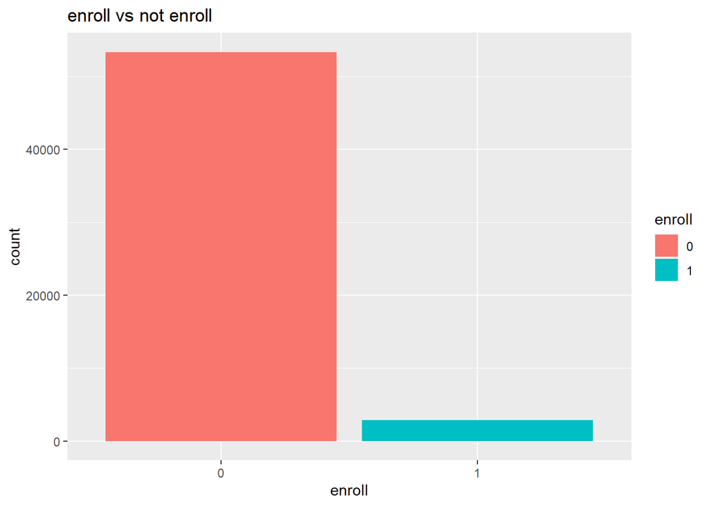

```r
data$enroll <- as.factor(data$enroll)

data %>%
  ggplot(aes(x=enroll, fill=enroll)) +
  geom_histogram(stat="count") +
  labs(title = "enroll vs not enroll")
```

```r
data %>%
  group_by(enroll) %>%
  summarize(n=n()) %>%
  ungroup() %>%
  mutate(pct = n/sum(n))
```

| enroll | n | pct |
| --- | --- | --- |
| 0 | 53369 | 0.94900155 |
| 1 | 2868 | 0.05099845 |

## Explore numerics

Compare numeric variables by comparing histograms of respond vs non-respond of course you can follow up with descriptive statistics too…

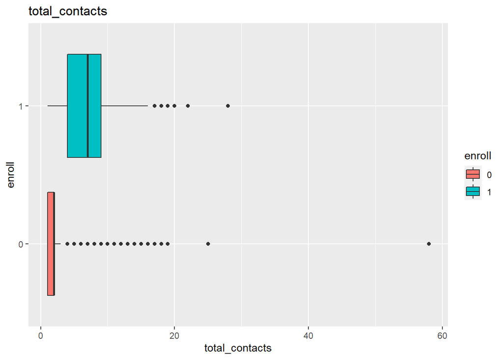

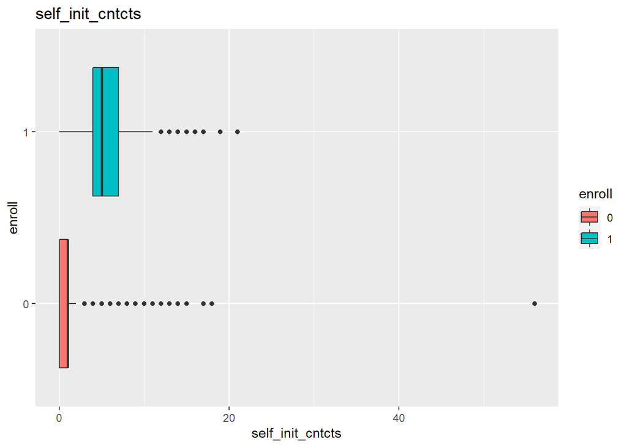

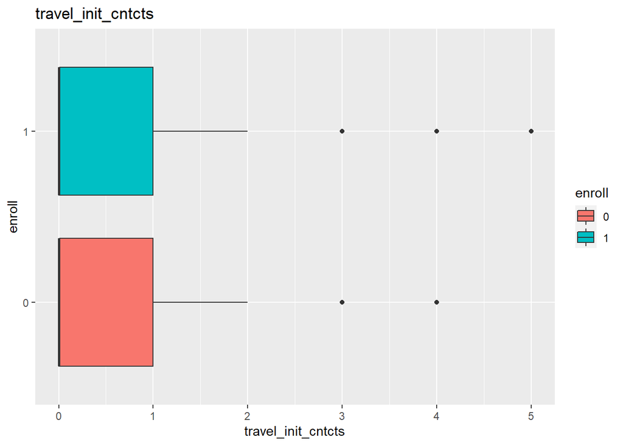

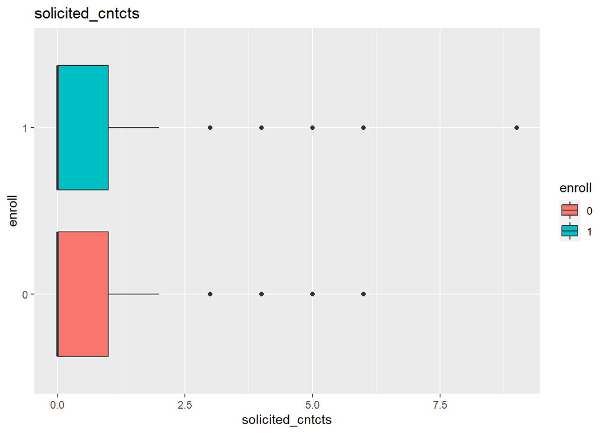

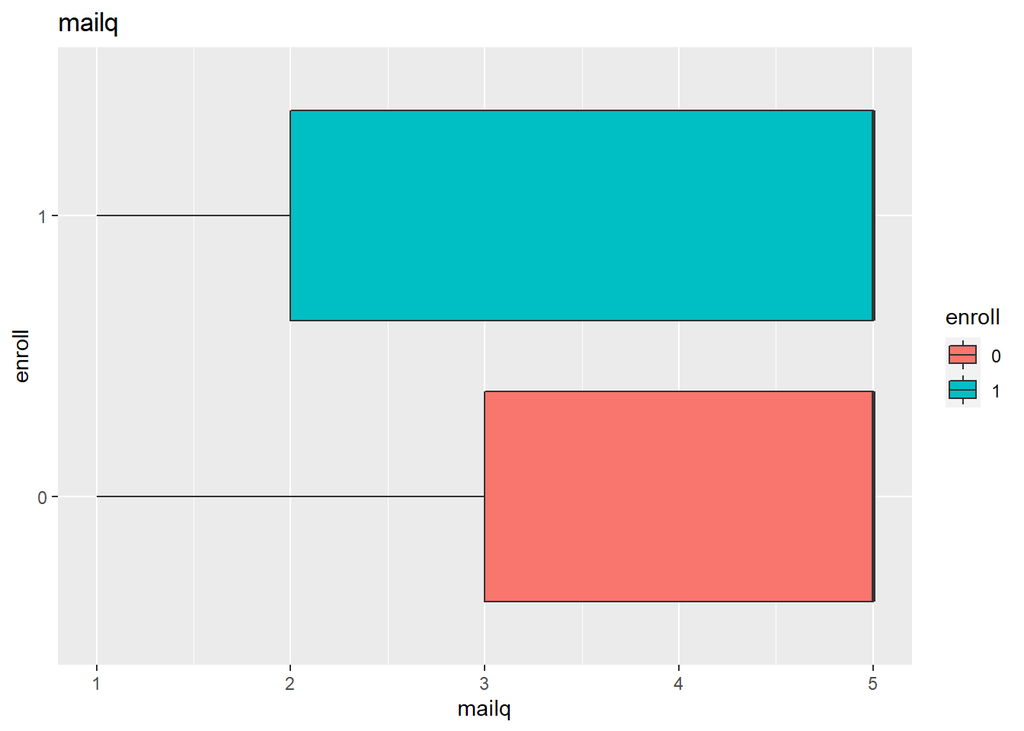

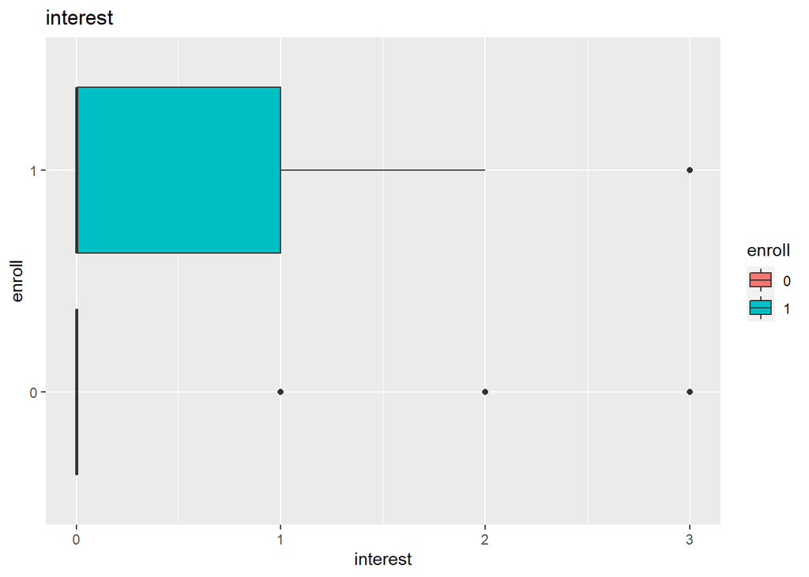

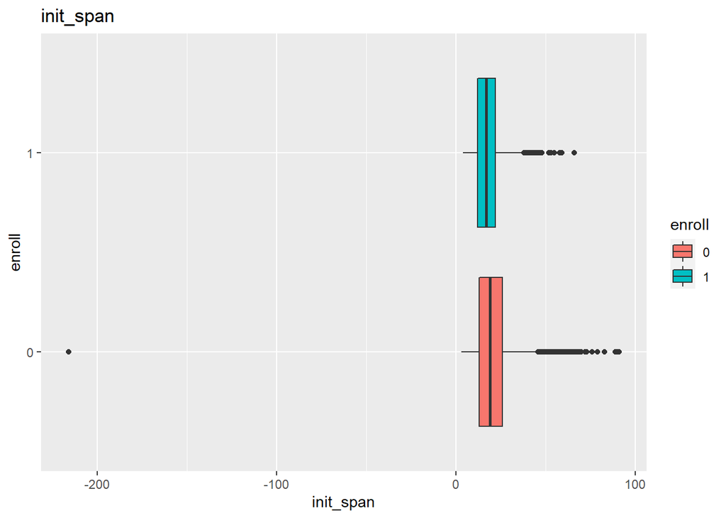

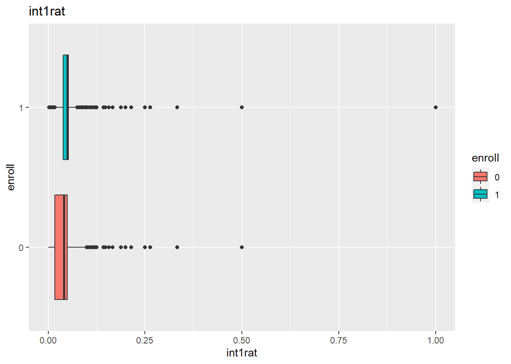

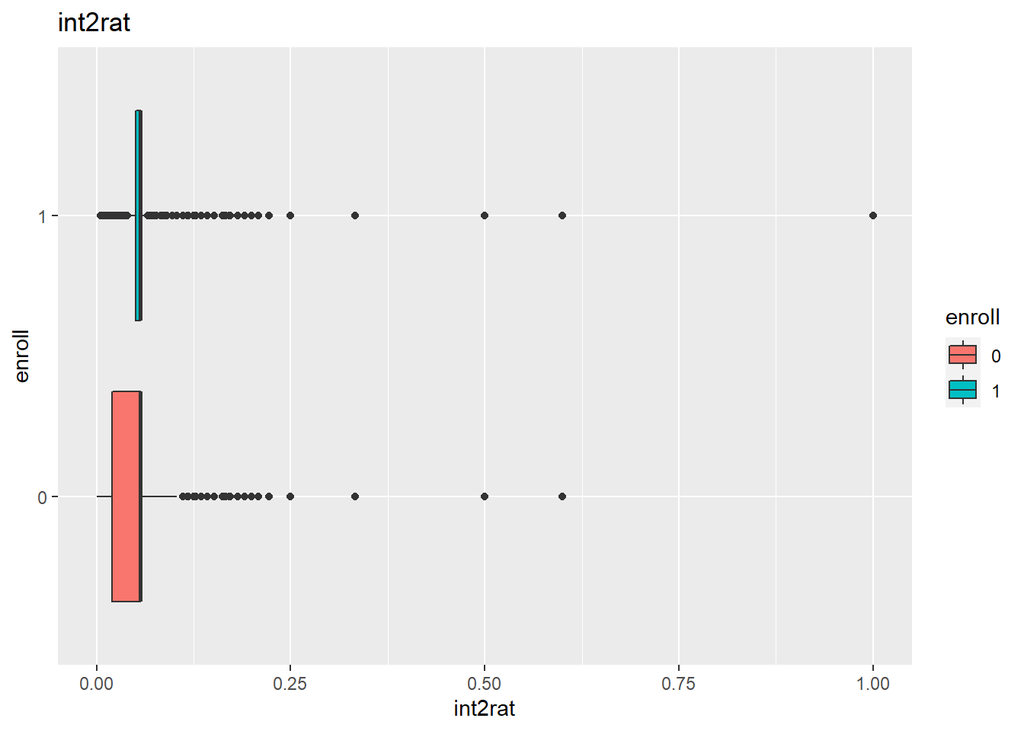

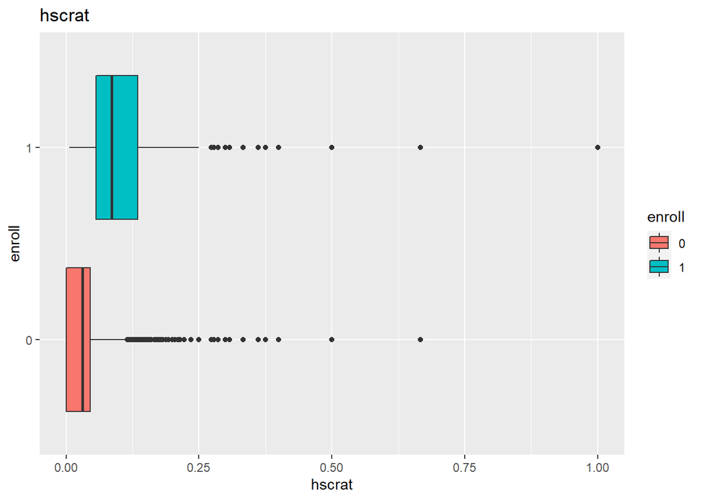

```r
# -- comparative boxplots

boxplot <- function(m){
    ggplot(data, aes(x=!!as.name(m), y=enroll, fill=enroll)) +
    geom_boxplot() +
    labs(title = as.character(m))
}

numerics <- c("total_contacts", "self_init_cntcts", "travel_init_cntcts", "solicited_cntcts", "mailq", "interest", "init_span", "int1rat", "int2rat", "hscrat")

for (c in numerics){
    print(boxplot(c))
}
```

## Explore character variables

cycle through each character column and look for separation for respond vs non-respond

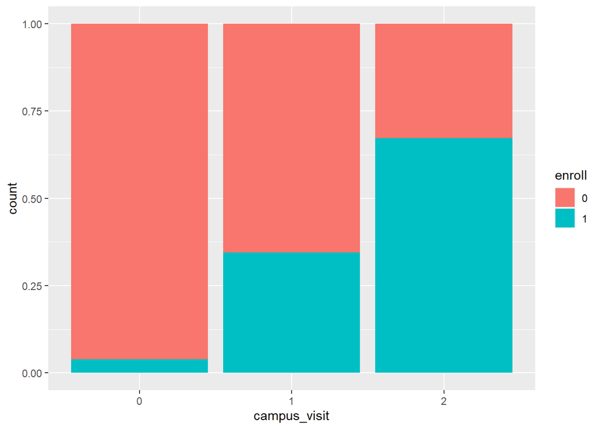

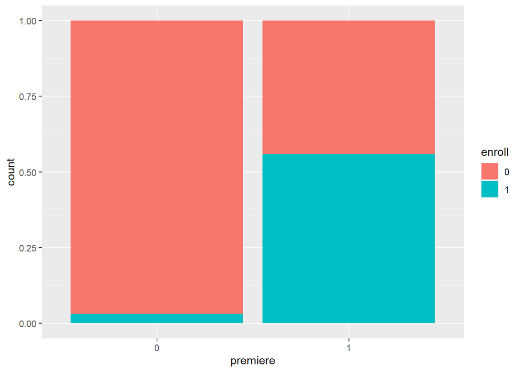

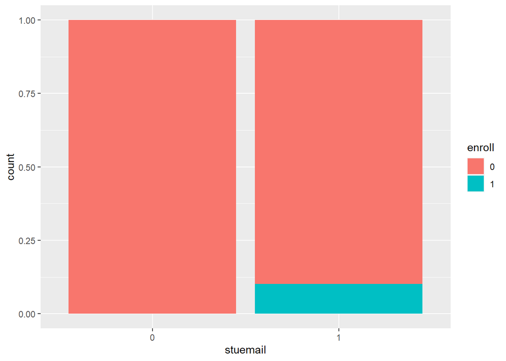

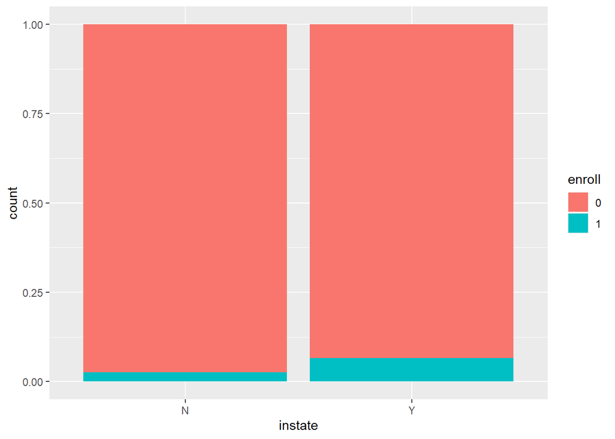

```r
char_explore <- function(col){
    data %>%
    ggplot(aes(!!as.name(col))) +
    geom_bar(aes(fill = enroll), position = "fill")
}

data$campus_visit <- as.character(data$campus_visit)
data$premiere <- as.character(data$premiere)
data$stuemail <- as.character(data$stuemail)

# -- for each character column, create a chart
for (column in names(data %>% select_if (is_character))){
    chrt <- char_explore(column)
    print(chrt)
}
```

## 0. Make Factors!

The next step for us is to create a dataset for modeling. Let’s include a set of all of the columns we are interested in, and convert all the **character columns** to **factors** as well as any “nominal” or low frequency numeric columns likely to be a factor. This is done for the modeling functions coming later.

```r
data %>%
    mutate_if(is.character, factor)  -> data_prep

head(data_prep)
```

| enroll | total_contacts | self_init_cntcts | travel_init_cntcts | solicited_cntcts | campus_visit | mailq | premiere | interest | stuemail | init_span | int1rat | int2rat | hscrat | instate |
| --- | --- | --- | --- | --- | --- | --- | --- | --- | --- | --- | --- | --- | --- | --- |
| 1 | 1 | 1 | 0 | 0 | 0 | 5 | 0 | 1 | 1 | 10 | 0.01718275 | 0.02038 | 0.15789474 | N |
| 1 | 8 | 7 | 1 | 0 | 0 | 1 | 1 | 0 | 1 | 28 | 0.01718275 | 0.02038 | 0.07857143 | N |
| 1 | 1 | 1 | 0 | 0 | 0 | 5 | 0 | 0 | 1 | 9 | 0.01718275 | 0.02038 | 0.11111111 | N |
| 1 | 6 | 6 | 0 | 0 | 0 | 5 | 0 | 0 | 1 | 17 | 0.01718275 | 0.02038 | 0.25000000 | N |
| 1 | 1 | 1 | 0 | 0 | 0 | 5 | 0 | 0 | 1 | 8 | 0.01718275 | 0.02038 | 0.33333333 | N |
| 1 | 3 | 3 | 0 | 0 | 0 | 5 | 0 | 0 | 1 | 10 | 0.01718275 | 0.02038 | 0.33333333 | N |

## 1. Partition my data 70/30 (train / test split)

```r
# -- set a random seed for repeatablity
set.seed(1234)

# -- performs our train / test split
data_split <- initial_split(data_prep, prop = 0.7)

# -- extract the training data
data_train <- training(data_split)
# -- extract the test data
data_test <- testing(data_split)

sprintf("Train PCT : %1.2f%%", nrow(data_train)/ nrow(data) * 100)
```

```
## [1] "Train PCT : 70.00%"
```

```r
sprintf("Test  PCT : %1.2f%%", nrow(data_test)/ nrow(data) * 100)
```

```
## [1] "Test  PCT : 30.00%"
```

## 2. Recipe

```r
# -- create our recipe --
data_recipe <- recipe(enroll ~ ., data = data_train) %>%
#  step_rm(duration) %>%
  step_impute_mode(all_nominal(), -all_outcomes()) %>%
  step_impute_median(all_numeric()) %>%
  step_dummy(all_nominal(), -all_outcomes()) %>%
  prep()

data_recipe
```

```
## Recipe
##
## Inputs:
##
##       role #variables
##    outcome          1
##  predictor         14
##
## Training data contained 39365 data points and no missing data.
##
## Operations:
##
## Mode imputation for campus_visit, premiere, stuemail, instate [trained]
## Median imputation for total_contacts, self_init_cntcts, travel_init_c... [trained]
## Dummy variables from campus_visit, premiere, stuemail, instate [trained]
```

## 3. Bake

```r
# -- apply the recipe
bake_train <- bake(data_recipe, new_data = data_train)
bake_test  <- bake(data_recipe, new_data = data_test)
```

## 4. Fit

```r
## logistic code is here for reference and comparison

logistic_glm <-logistic_reg(mode = "classification") %>%
                  set_engine("glm") %>%
                  fit(enroll ~ ., data = bake_train)

## -- check out your parameter estimates ...
tidy(logistic_glm) %>%
  mutate_at(c("estimate", "std.error", "statistic", "p.value"),round, 4)
```

| term | estimate | std.error | statistic | p.value |
| --- | --- | --- | --- | --- |
| (Intercept) | -24.0851 | 190.3719 | -0.1265 | 0.8993 |
| total_contacts | 0.3869 | 0.1152 | 3.3578 | 0.0008 |
| self_init_cntcts | 0.1239 | 0.1174 | 1.0552 | 0.2913 |
| travel_init_cntcts | -0.0280 | 0.1276 | -0.2195 | 0.8263 |
| solicited_cntcts | -0.4336 | 0.1216 | -3.5669 | 0.0004 |
| mailq | 0.1871 | 0.0252 | 7.4171 | 0.0000 |
| interest | 0.5605 | 0.0746 | 7.5124 | 0.0000 |
| init_span | -0.0587 | 0.0051 | -11.4447 | 0.0000 |
| int1rat | 5.2312 | 1.2619 | 4.1455 | 0.0000 |
| int2rat | 5.6289 | 1.1038 | 5.0997 | 0.0000 |

[output cut: 6 more lines]

## 5. Prep for Evaluation

We want to attach both the Predicted Probabilities (.pred_No, .pred_Yes) and the Predicted Class (.pred_class) to the dataset so we can deep dive into where out model is performing well and where it’s not. We do this to both the Training and the Test set.

```r
# -- training
predict(logistic_glm, bake_train, type = "prob") %>%
  bind_cols(.,predict(logistic_glm, bake_train)) %>%
  bind_cols(.,bake_train) -> scored_train_glm

head(scored_train_glm)
```

| .pred_0 | .pred_1 | .pred_class | total_contacts | self_init_cntcts | travel_init_cntcts | solicited_cntcts | mailq | interest | init_span | int1rat | int2rat | hscrat | enroll | campus_visit_X1 | campus_visit_X2 | premiere_X1 | stuemail_X1 | instate_Y |
| --- | --- | --- | --- | --- | --- | --- | --- | --- | --- | --- | --- | --- | --- | --- | --- | --- | --- | --- |
| 0.9541034 | 4.589657e-02 | 0 | 2 | 1 | 1 | 0 | 1 | 0 | 21 | 0.14759036 | 0.055555556 | 0.10810811 | 0 | 0 | 0 | 0 | 1 | 1 |
| 1.0000000 | 1.245570e-10 | 0 | 1 | 0 | 0 | 1 | 5 | 0 | 10 | 0.04926967 | 0.056669686 | 0.00000000 | 0 | 0 | 0 | 0 | 0 | 1 |
| 0.9132568 | 8.674321e-02 | 0 | 7 | 4 | 1 | 1 | 1 | 0 | 19 | 0.04838710 | 0.028169014 | 0.05617978 | 0 | 0 | 0 | 0 | 1 | 1 |
| 0.9984921 | 1.507886e-03 | 0 | 1 | 0 | 0 | 1 | 5 | 0 | 31 | 0.01287001 | 0.006535948 | 0.00000000 | 0 | 0 | 0 | 0 | 1 | 0 |
| 1.0000000 | 9.869545e-11 | 0 | 1 | 0 | 0 | 1 | 5 | 0 | 31 | 0.05235325 | 0.088541667 | 0.06557377 | 0 | 0 | 0 | 0 | 0 | 1 |
| 1.0000000 | 1.005288e-10 | 0 | 1 | 0 | 1 | 0 | 2 | 0 | 11 | 0.04926967 | 0.056669686 | 0.00000000 | 0 | 0 | 0 | 0 | 0 | 1 |

```r
# -- testing
predict(logistic_glm, bake_test, type = "prob") %>%
  bind_cols(.,predict(logistic_glm, bake_test)) %>%
  bind_cols(.,bake_test) -> scored_test_glm

head(scored_test_glm)
```

| .pred_0 | .pred_1 | .pred_class | total_contacts | self_init_cntcts | travel_init_cntcts | solicited_cntcts | mailq | interest | init_span | int1rat | int2rat | hscrat | enroll | campus_visit_X1 | campus_visit_X2 | premiere_X1 | stuemail_X1 | instate_Y |
| --- | --- | --- | --- | --- | --- | --- | --- | --- | --- | --- | --- | --- | --- | --- | --- | --- | --- | --- |
| 8.917703e-01 | 0.10822973 | 0 | 1 | 1 | 0 | 0 | 5 | 1 | 10 | 0.01718275 | 0.02038000 | 0.15789474 | 1 | 0 | 0 | 0 | 1 | 0 |
| 9.602403e-01 | 0.03975973 | 0 | 1 | 1 | 0 | 0 | 5 | 0 | 9 | 0.01718275 | 0.02038000 | 0.11111111 | 1 | 0 | 0 | 0 | 1 | 0 |
| 3.535963e-01 | 0.64640367 | 1 | 6 | 6 | 0 | 0 | 5 | 0 | 17 | 0.01718275 | 0.02038000 | 0.25000000 | 1 | 0 | 0 | 0 | 1 | 0 |
| 1.807514e-04 | 0.99981925 | 1 | 3 | 3 | 0 | 0 | 5 | 0 | 11 | 0.01718275 | 0.02038000 | 1.00000000 | 1 | 0 | 0 | 0 | 1 | 0 |
| 9.537229e-01 | 0.04627712 | 0 | 2 | 2 | 0 | 0 | 5 | 0 | 11 | 0.01718275 | 0.02038000 | 0.09195402 | 1 | 0 | 0 | 0 | 1 | 0 |
| 5.065245e-06 | 0.99999493 | 1 | 10 | 10 | 0 | 0 | 2 | 0 | 23 | 0.08333333 | 0.01123596 | 1.00000000 | 1 | 1 | 0 | 0 | 1 | 0 |

## 6. Evaluate

We want to check our model’s performance and take a look at which features were most important.

```r
options(yardstick.event_first = FALSE)

# -- AUC: Train and Test
scored_train_glm %>%
  metrics(enroll, .pred_1, estimate = .pred_class) %>%
  mutate(part="training") %>%
  bind_rows( scored_test_glm %>%
               metrics(enroll, .pred_1, estimate = .pred_class) %>%
               mutate(part="testing")
  ) %>%
  filter(.metric %in% c("accuracy", "roc_auc"))
```

| .metric | .estimator | .estimate | part |
| --- | --- | --- | --- |
| accuracy | binary | 0.9655532 | training |
| roc_auc | binary | 0.9779126 | training |
| accuracy | binary | 0.9650308 | testing |
| roc_auc | binary | 0.9786638 | testing |

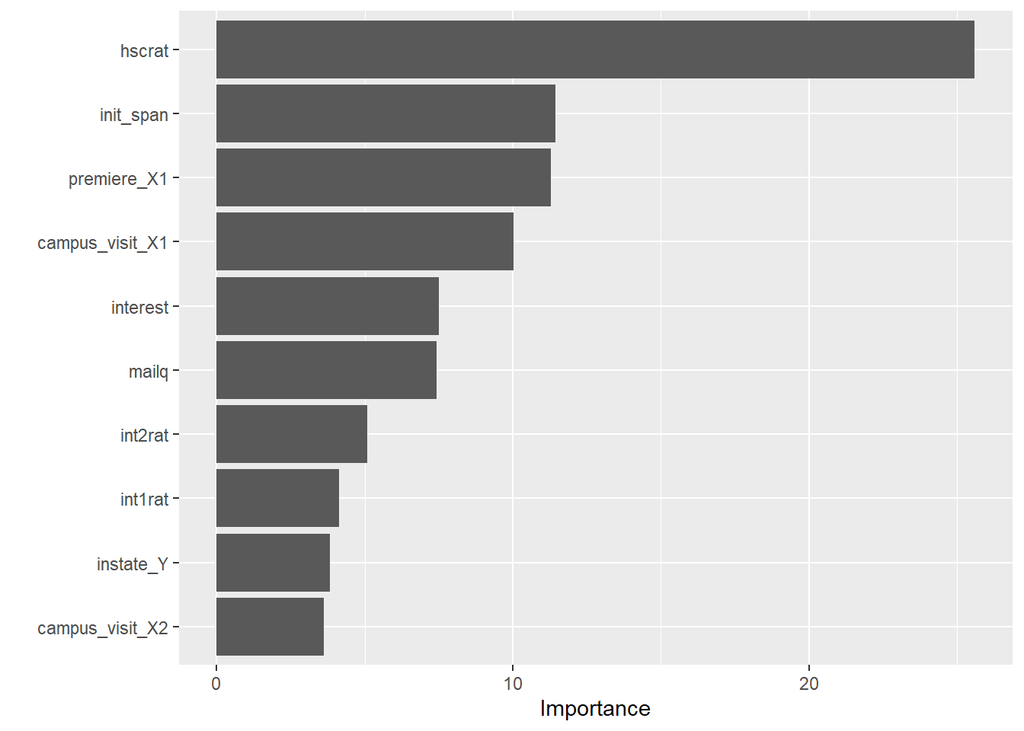

```r
# -- Variable Importance top 10 features
logistic_glm %>%
  vip(num_features = 10)
```

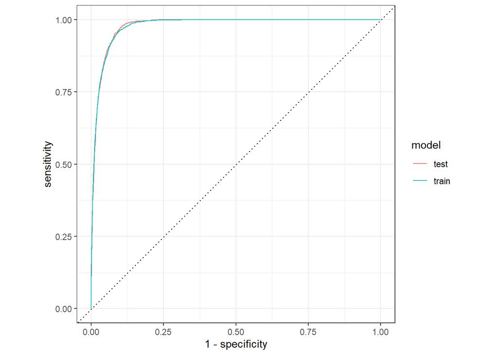

```r
# -- ROC Charts
scored_train_glm %>%
  mutate(model = "train") %>%
  bind_rows(scored_test_glm %>%
              mutate(model="test")) %>%
  group_by(model) %>%
  roc_curve(enroll, .pred_1) %>%
  autoplot()
```

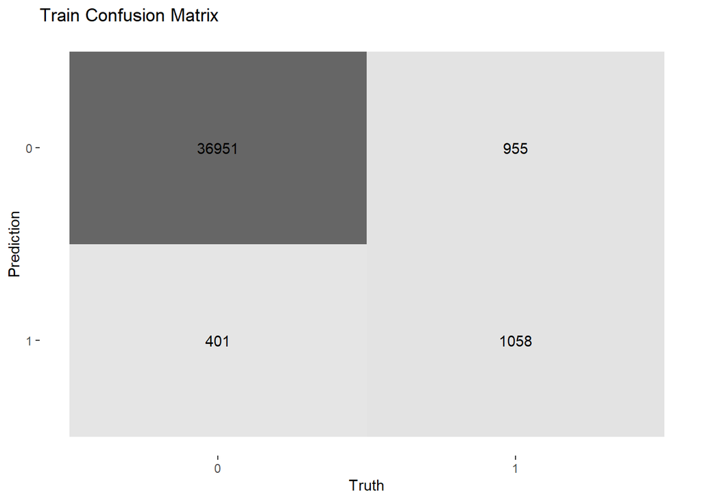

```r
# -- Confustion Matricies
scored_train_glm %>%
  conf_mat(enroll, .pred_class) %>%
  autoplot( type = "heatmap") +
  labs(title="Train Confusion Matrix")
```

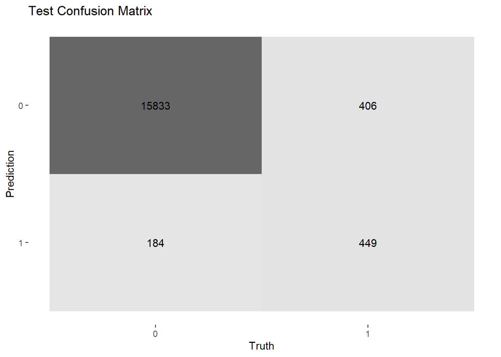

```r
scored_test_glm %>%
  conf_mat(enroll, .pred_class) %>%
  autoplot( type = "heatmap") +
  labs(title="Test Confusion Matrix")
```

```r
## -- Use stepwise selection to reduce the model

steplog <- glm(enroll ~ ., data = bake_train, family=binomial(link="logit"))
step <- stepAIC(steplog, direction="both")
```

```
## Start:  AIC=6577.81
## enroll ~ total_contacts + self_init_cntcts + travel_init_cntcts +
##     solicited_cntcts + mailq + interest + init_span + int1rat +
##     int2rat + hscrat + campus_visit_X1 + campus_visit_X2 + premiere_X1 +
##     stuemail_X1 + instate_Y
##
##                      Df Deviance    AIC
## - travel_init_cntcts  1   6545.9 6575.9
## - self_init_cntcts    1   6546.9 6576.9
## <none>                    6545.8 6577.8
## - total_contacts      1   6556.9 6586.9
## - solicited_cntcts    1   6558.3 6588.3
## - instate_Y           1   6560.7 6590.7
## - campus_visit_X2     1   6561.5 6591.5
## - int1rat             1   6563.3 6593.3
## - int2rat             1   6569.9 6599.9
## - interest            1   6600.5 6630.5
## - mailq               1   6602.4 6632.4
## - campus_visit_X1     1   6643.9 6673.9
## - premiere_X1         1   6672.1 6702.1
## - init_span           1   6691.3 6721.3
## - stuemail_X1         1   7362.8 7392.8
## - hscrat              1   7625.7 7655.7
##
## Step:  AIC=6575.85
## enroll ~ total_contacts + self_init_cntcts + solicited_cntcts +
##     mailq + interest + init_span + int1rat + int2rat + hscrat +
##     campus_visit_X1 + campus_visit_X2 + premiere_X1 + stuemail_X1 +
##     instate_Y
##
##                      Df Deviance    AIC
## <none>                    6545.9 6575.9
## + travel_init_cntcts  1   6545.8 6577.8
## - self_init_cntcts    1   6552.3 6580.3
## - instate_Y           1   6560.7 6588.7
## - campus_visit_X2     1   6561.6 6589.6
## - int1rat             1   6563.3 6591.3
## - int2rat             1   6569.9 6597.9
## - solicited_cntcts    1   6583.9 6611.9
## - total_contacts      1   6589.4 6617.4
## - interest            1   6600.6 6628.6
## - mailq               1   6606.4 6634.4
## - campus_visit_X1     1   6644.3 6672.3
## - premiere_X1         1   6672.1 6700.1
## - init_span           1   6691.3 6719.3
## - stuemail_X1         1   7363.6 7391.6
## - hscrat              1   7629.1 7657.1
```

```r
summary(step)
```

```
##
## Call:
## glm(formula = enroll ~ total_contacts + self_init_cntcts + solicited_cntcts +
##     mailq + interest + init_span + int1rat + int2rat + hscrat +
##     campus_visit_X1 + campus_visit_X2 + premiere_X1 + stuemail_X1 +
##     instate_Y, family = binomial(link = "logit"), data = bake_train)
##
## Deviance Residuals:
##    Min      1Q  Median      3Q     Max
## -6.889  -0.157   0.000   0.000   3.085
##
## Coefficients:
##                    Estimate Std. Error z value Pr(>|z|)
## (Intercept)      -24.091477 190.372752  -0.127 0.899297
## total_contacts     0.364734   0.055218   6.605 3.97e-11 ***
## self_init_cntcts   0.146319   0.057927   2.526 0.011540 *
## solicited_cntcts  -0.411363   0.066946  -6.145 8.01e-10 ***
## mailq              0.188336   0.024579   7.663 1.82e-14 ***
## interest           0.560530   0.074607   7.513 5.78e-14 ***
## init_span         -0.058650   0.005125 -11.443  < 2e-16 ***
## int1rat            5.231269   1.261863   4.146 3.39e-05 ***
## int2rat            5.622590   1.103444   5.095 3.48e-07 ***
## hscrat            12.264189   0.478629  25.624  < 2e-16 ***
## campus_visit_X1    0.970875   0.096717  10.038  < 2e-16 ***
## campus_visit_X2    2.119043   0.585656   3.618 0.000297 ***
## premiere_X1        1.044916   0.092643  11.279  < 2e-16 ***
## stuemail_X1       18.414758 190.372655   0.097 0.922941
## instate_Y          0.399986   0.104936   3.812 0.000138 ***
## ---
## Signif. codes:  0 '***' 0.001 '**' 0.01 '*' 0.05 '.' 0.1 ' ' 1
##
## (Dispersion parameter for binomial family taken to be 1)
##
##     Null deviance: 15891.6  on 39364  degrees of freedom
## Residual deviance:  6545.9  on 39350  degrees of freedom
## AIC: 6575.9
##
## Number of Fisher Scoring iterations: 20
```

```r
## -- remove insignificant variable (stuemail)

model_1 <- glm(enroll ~ total_contacts + self_init_cntcts + solicited_cntcts + mailq + interest + init_span + int1rat + int2rat + hscrat + campus_visit + premiere + instate, data = data_train, family=binomial(link="logit"))

model_1
```

```
##
## Call:  glm(formula = enroll ~ total_contacts + self_init_cntcts + solicited_cntcts +
##     mailq + interest + init_span + int1rat + int2rat + hscrat +
##     campus_visit + premiere + instate, family = binomial(link = "logit"),
##     data = data_train)
##
## Coefficients:
##      (Intercept)    total_contacts  self_init_cntcts  solicited_cntcts
##         -6.29381           0.43612           0.17495          -0.37087
##            mailq          interest         init_span           int1rat
##          0.17161           0.67259          -0.06979           6.08524
##          int2rat            hscrat     campus_visit1     campus_visit2
##          6.36424          11.84376           1.02076           2.30075
##        premiere1          instateY
##          0.99552           0.33732
##
## Degrees of Freedom: 39364 Total (i.e. Null);  39351 Residual
## Null Deviance:       15890
## Residual Deviance: 7364  AIC: 7392
```

```r
summary(model_1)
```

```
##
## Call:
## glm(formula = enroll ~ total_contacts + self_init_cntcts + solicited_cntcts +
##     mailq + interest + init_span + int1rat + int2rat + hscrat +
##     campus_visit + premiere + instate, family = binomial(link = "logit"),
##     data = data_train)
##
## Deviance Residuals:
##     Min       1Q   Median       3Q      Max
## -7.5931  -0.1710  -0.1081  -0.0689   3.3958
##
## Coefficients:
##                  Estimate Std. Error z value Pr(>|z|)
## (Intercept)      -6.29381    0.17880 -35.201  < 2e-16 ***
## total_contacts    0.43612    0.05528   7.889 3.05e-15 ***
## self_init_cntcts  0.17495    0.05771   3.031 0.002435 **
## solicited_cntcts -0.37087    0.06741  -5.502 3.76e-08 ***
## mailq             0.17161    0.02466   6.959 3.44e-12 ***
## interest          0.67259    0.07500   8.967  < 2e-16 ***
## init_span        -0.06979    0.00525 -13.294  < 2e-16 ***
## int1rat           6.08524    1.26853   4.797 1.61e-06 ***
## int2rat           6.36424    1.13283   5.618 1.93e-08 ***
## hscrat           11.84376    0.42333  27.977  < 2e-16 ***
## campus_visit1     1.02076    0.09660  10.567  < 2e-16 ***
## campus_visit2     2.30075    0.61208   3.759 0.000171 ***
## premiere1         0.99552    0.09209  10.811  < 2e-16 ***
## instateY          0.33732    0.10491   3.215 0.001303 **
## ---
## Signif. codes:  0 '***' 0.001 '**' 0.01 '*' 0.05 '.' 0.1 ' ' 1
##
## (Dispersion parameter for binomial family taken to be 1)
##
##     Null deviance: 15891.6  on 39364  degrees of freedom
## Residual deviance:  7363.6  on 39351  degrees of freedom
## AIC: 7391.6
##
## Number of Fisher Scoring iterations: 25
```

```r
## -- Use tidymodel framework to fit and evaulate reduced model

uni_steprecipe <- recipe(enroll ~ total_contacts + self_init_cntcts + solicited_cntcts + mailq + interest + init_span + int1rat + int2rat + hscrat + campus_visit + premiere + instate, data = data_train) %>%
    step_impute_median(all_numeric()) %>%
    prep()

uni_steprecipe
```

```
## Recipe
##
## Inputs:
##
##       role #variables
##    outcome          1
##  predictor         12
##
## Training data contained 39365 data points and no missing data.
##
## Operations:
##
## Median imputation for total_contacts, self_init_cntcts, solicited_cnt... [trained]
```

```r
# -- apply new recipe
bake_steptrain <- bake(uni_steprecipe, new_data = data_train)
bake_steptest  <- bake(uni_steprecipe, new_data = data_test)

logistic_step1 <- logistic_reg(mode = "classification") %>%
                  set_engine("glm") %>%
                  fit(enroll ~ ., data = bake_steptrain)


## -- check out your parameter estimates ...
tidy(logistic_step1) %>%
  mutate_at(c("estimate", "std.error", "statistic", "p.value"),round, 4)
```

| term | estimate | std.error | statistic | p.value |
| --- | --- | --- | --- | --- |
| (Intercept) | -6.2938 | 0.1788 | -35.2005 | 0.0000 |
| total_contacts | 0.4361 | 0.0553 | 7.8887 | 0.0000 |
| self_init_cntcts | 0.1749 | 0.0577 | 3.0313 | 0.0024 |
| solicited_cntcts | -0.3709 | 0.0674 | -5.5018 | 0.0000 |
| mailq | 0.1716 | 0.0247 | 6.9585 | 0.0000 |
| interest | 0.6726 | 0.0750 | 8.9674 | 0.0000 |
| init_span | -0.0698 | 0.0053 | -13.2936 | 0.0000 |
| int1rat | 6.0852 | 1.2685 | 4.7971 | 0.0000 |
| int2rat | 6.3642 | 1.1328 | 5.6180 | 0.0000 |
| hscrat | 11.8438 | 0.4233 | 27.9773 | 0.0000 |

[output cut: 4 more lines]

```r
# -- training predictions from stepwise model
predict(logistic_step1, bake_steptrain, type = "prob") %>%
  bind_cols(.,predict(logistic_step1, bake_steptrain)) %>%
  bind_cols(.,bake_steptrain) -> scored_train_step1

head(scored_train_step1)
```

| .pred_0 | .pred_1 | .pred_class | total_contacts | self_init_cntcts | solicited_cntcts | mailq | interest | init_span | int1rat | int2rat | hscrat | campus_visit | premiere | instate | enroll |
| --- | --- | --- | --- | --- | --- | --- | --- | --- | --- | --- | --- | --- | --- | --- | --- |
| 0.9751860 | 0.0248140497 | 0 | 2 | 1 | 0 | 1 | 0 | 21 | 0.14759036 | 0.055555556 | 0.10810811 | 0 | 0 | Y | 0 |
| 0.9937606 | 0.0062394078 | 0 | 1 | 0 | 1 | 5 | 0 | 10 | 0.04926967 | 0.056669686 | 0.00000000 | 0 | 0 | Y | 0 |
| 0.9302196 | 0.0697803886 | 0 | 7 | 4 | 1 | 1 | 0 | 19 | 0.04838710 | 0.028169014 | 0.05617978 | 0 | 0 | Y | 0 |
| 0.9993977 | 0.0006023133 | 0 | 1 | 0 | 1 | 5 | 0 | 31 | 0.01287001 | 0.006535948 | 0.00000000 | 0 | 0 | N | 0 |
| 0.9960810 | 0.0039189841 | 0 | 1 | 0 | 1 | 5 | 0 | 31 | 0.05235325 | 0.088541667 | 0.06557377 | 0 | 0 | Y | 0 |
| 0.9949554 | 0.0050446364 | 0 | 1 | 0 | 0 | 2 | 0 | 11 | 0.04926967 | 0.056669686 | 0.00000000 | 0 | 0 | Y | 0 |

```r
# -- testing predictions from stepwise model
predict(logistic_step1, bake_steptest, type = "prob") %>%
  bind_cols(.,predict(logistic_step1, bake_steptest)) %>%
  bind_cols(.,bake_steptest) -> scored_test_step1

head(scored_test_step1)
```

| .pred_0 | .pred_1 | .pred_class | total_contacts | self_init_cntcts | solicited_cntcts | mailq | interest | init_span | int1rat | int2rat | hscrat | campus_visit | premiere | instate | enroll |
| --- | --- | --- | --- | --- | --- | --- | --- | --- | --- | --- | --- | --- | --- | --- | --- |
| 9.396685e-01 | 0.06033154 | 0 | 1 | 1 | 0 | 5 | 1 | 10 | 0.01718275 | 0.02038000 | 0.15789474 | 0 | 0 | N | 1 |
| 9.802095e-01 | 0.01979047 | 0 | 1 | 1 | 0 | 5 | 0 | 9 | 0.01718275 | 0.02038000 | 0.11111111 | 0 | 0 | N | 1 |
| 4.404356e-01 | 0.55956439 | 1 | 6 | 6 | 0 | 5 | 0 | 17 | 0.01718275 | 0.02038000 | 0.25000000 | 0 | 0 | N | 1 |
| 4.491213e-04 | 0.99955088 | 1 | 3 | 3 | 0 | 5 | 0 | 11 | 0.01718275 | 0.02038000 | 1.00000000 | 0 | 0 | N | 1 |
| 9.748635e-01 | 0.02513652 | 0 | 2 | 2 | 0 | 5 | 0 | 11 | 0.01718275 | 0.02038000 | 0.09195402 | 0 | 0 | N | 1 |
| 6.156524e-06 | 0.99999384 | 1 | 10 | 10 | 0 | 2 | 0 | 23 | 0.08333333 | 0.01123596 | 1.00000000 | 1 | 0 | N | 1 |

```r
# -- Evaluate Stepwise Model
# -- AUC: Train and Test
options(yardstick.event_first = FALSE)

scored_train_step1 %>%
  metrics(enroll, .pred_1, estimate = .pred_class) %>%
  mutate(part="training") %>%
  bind_rows( scored_test_step1 %>%
               metrics(enroll, .pred_1, estimate = .pred_class) %>%
               mutate(part="testing")
  ) %>%
  filter(.metric %in% c("accuracy", "roc_auc"))
```

| .metric | .estimator | .estimate | part |
| --- | --- | --- | --- |
| accuracy | binary | 0.9640290 | training |
| roc_auc | binary | 0.9705458 | training |
| accuracy | binary | 0.9640825 | testing |
| roc_auc | binary | 0.9725269 | testing |

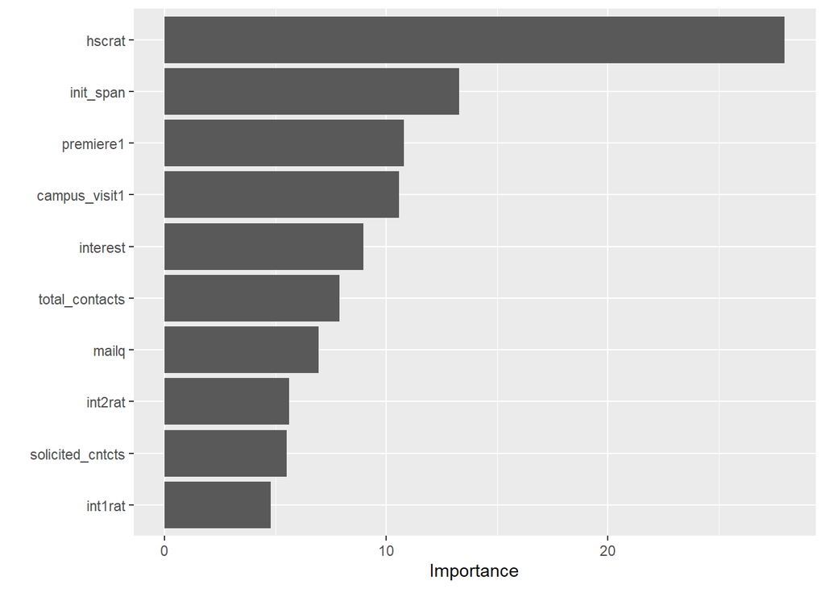

```r
# -- Variable Importance top 10 features
model_1 %>%
  vip(num_features = 10)
```

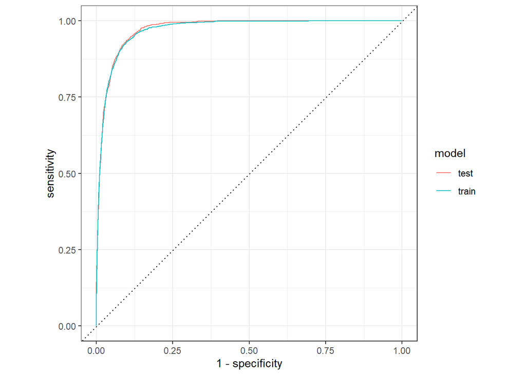

```r
# -- ROC Charts
scored_train_step1 %>%
  mutate(model = "train") %>%
  bind_rows(scored_test_step1 %>%
              mutate(model="test")) %>%
  group_by(model) %>%
  roc_curve(enroll, .pred_1) %>%
  autoplot()
```

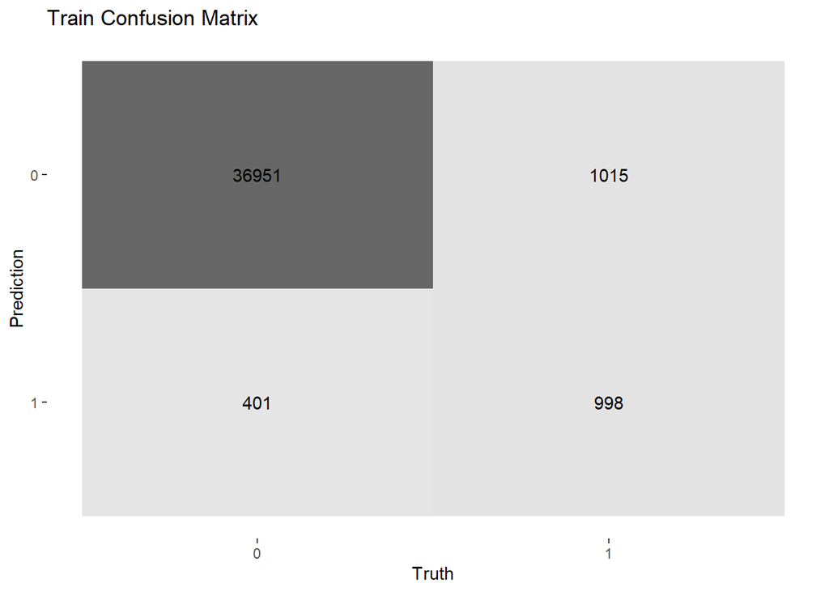

```r
# -- Confustion Matricies
scored_train_step1 %>%
  conf_mat(enroll, .pred_class) %>%
  autoplot(type = "heatmap") +
  labs(title="Train Confusion Matrix")
```

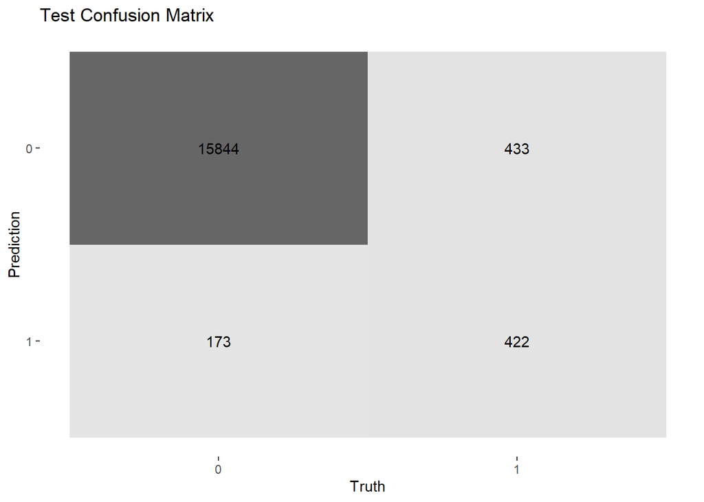

```r
scored_test_step1 %>%
  conf_mat(enroll, .pred_class) %>%
  autoplot(type = "heatmap") +
  labs(title="Test Confusion Matrix")
```